# Stimulus selection

Jörn Alexander Quent

12 January 2018

# Introduction

The aim is to select a certain number (20) of combinations of objects and locations that cover the whole range of expectancy values. The previous analysis of this data set can be found [here](https://jaquent.github.io/2018/0110_ratingAnalysis.html). The code for the task can be found [here](https://github.com/JAQuent/ratingStudy).

## Used libraries and functions

```r
library(ggplot2)
```

## Loading the rating data

I start with loading the raw data and creating a 20 x 20 x N matrix holding all 400 location ratings for all participants.

```r
# Prepare
subNo           <- 1:6
N               <- length(subNo)
locationRatings <- array(data = NA, dim = c(20, 20, N))

# Sequently loading data
for(i in 1:N){
  locationRatings[,,i] <- matrix(scan(paste('data/locationRatings_', as.character(subNo[i]) ,'.dat', sep = '')), byrow = TRUE, ncol = 20)
}
```

## Raking the ratings within each participants

Now I will rank all ratings within each participant and to create one matrix containing the averaged ranks. I first try to use *order()* to rank this data, but this does not work at all and then I found that there is function called *rank()*, which does the job perfectly.

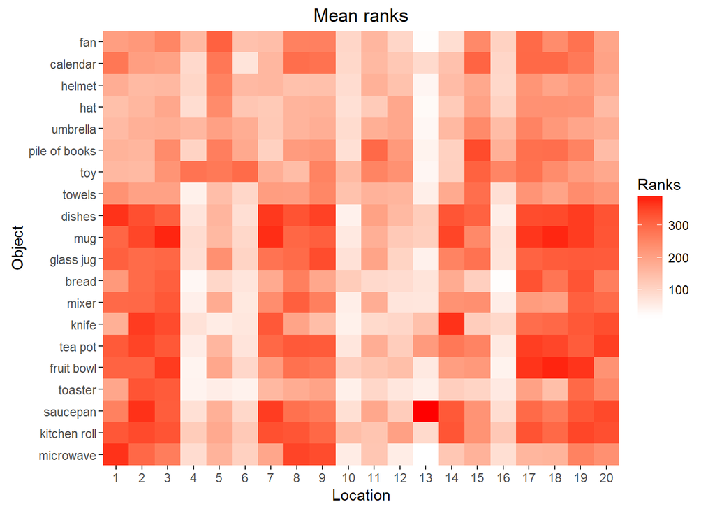

```r
# Calculate ranks
rankedRatings <- array(data = NA, dim = c(20, 20, N))

for(i in 1:N){
  rankedRatings[,,i] <- rank(locationRatings[,,i])
}


# Calculate mean rank per object/ location
meanRankedRatings <- apply(rankedRatings, 1:2, mean)

# Plot heatmap
objectNames <- c('microwave','kitchen roll','saucepan', 'toaster','fruit bowl','tea pot','knife','mixer','bread','glass jug','mug','dishes','towels','toy','pile of books','umbrella','hat','helmet','calendar','fan')

meanRankedRatingsDF <- data.frame(Object = rep(factor(1:20, labels = objectNames), 20), Location = as.factor(rep(1:20, each = 20)), Ranks = c(meanRankedRatings))

ggplot(meanRankedRatingsDF, aes(Location, Object)) + geom_tile(aes(fill = Ranks)) + scale_fill_gradient(low = "white", high = "red") + scale_x_discrete(expand = c(0, 0)) +  scale_y_discrete(expand = c(0, 0)) + labs(title = 'Mean ranks')
```

The heatmap basically looks exactly like the heatmap based on the mean unranked ratings (to be found [here](https://jaquent.github.io/2018/0110_ratingAnalysis.html)).

## Selection of object/location combinations

Now, my aim is to find the best set of object/location combinations. The first step is to find a location for each object in a way that ensures that range of expectancy values spreads across the whole scale. The aim is to find a set of values that closely matches our linearly spaced target spread:

```r
targetSpread <- seq(1, 400,length = 20)
targetSpread
```

```
##  [1]   1  22  43  64  85 106 127 148 169 190 211 232 253 274 295 316 337
## [18] 358 379 400
```

I try that with a brute force approach by randomly selecting twenty object/location combinations and has the lowest summed squared deviation from our target spread (see above).

```r
# Preparation
numberObjects <- 20
iterations    <- 100000
locations     <- matrix(NA, nrow = numberObjects, ncol = iterations)
meanRanks     <- matrix(NA, nrow = numberObjects, ncol = iterations)
differences   <- rep(NA, iterations)

# Sample differences
for(i in 1:iterations){
  locations[,i] <- sample(1:numberObjects)
  for(j in 1:numberObjects){
    meanRanks[j, i] <- meanRankedRatings[j, locations[j,i]] # Extracting the mean ranks
  }
  differences[i] <- sum((sort(meanRanks[, i]) - targetSpread)^2) # Calculating summed squared deviation
}
```

The lowest summed squared deviation is 2417.4583333 found after 10^{5} iterations.

```r
round(sort(meanRanks[, differences == min(differences)]))
```

```
##  [1]  28  33  47  80  91  94 139 153 168 202 216 225 260 282 296 326 329
## [18] 357 369 380
```

```r
targetSpread
```

```
##  [1]   1  22  43  64  85 106 127 148 169 190 211 232 253 274 295 316 337
## [18] 358 379 400
```

The selected combination comes very close to the target spread as you see above where I juxtaposed both.

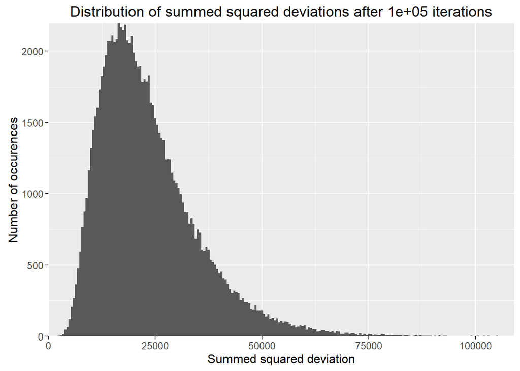

```r
# Visualisation
ggplot(data.frame(differences), aes(differences)) + geom_histogram(binwidth = 500) + theme(panel.margin = unit(1, "cm"), text = element_text(size = 12)) +
        labs(y = 'Number of occurences', x = 'Summed squared deviation', title = paste('Distribution of summed squared deviations after', iterations, 'iterations')) + coord_cartesian(xlim = c(0, 109000), expand = FALSE)
```

## Selection of foils

Now it is time to find the two foils for each object that have the closest in terms of expectancy to the selected test location.

```r
selectedLocations <- locations[, differences == min(differences)]
foils             <- matrix(NA, nrow = numberObjects, ncol = 2)
foilsRank         <- matrix(NA, nrow = numberObjects, ncol = 2)

for(i in 1:numberObjects){
  absDifference      <- abs(meanRankedRatings[i, selectedLocations[i]] - meanRankedRatings[i,]) # Calculating the absolute difference
  foil1absDifference <- sort(abs(meanRankedRatings[i, selectedLocations[i]] - meanRankedRatings[i,]))[2] # Sort differences and compare to select location and select nearest
  foil2absDifference <- sort(abs(meanRankedRatings[i, selectedLocations[i]] - meanRankedRatings[i,]))[3] # Sort differences and compare to select location and select second neasted
  # The following sections jsut deals if the case when more than one values is the nearest
  if(length(c(1:20)[absDifference == foil1absDifference]) == 1){
     foils[i, 1]     <-  c(1:20)[absDifference == foil1absDifference][1] #
     foils[i, 2]     <-  c(1:20)[absDifference == foil2absDifference][1]
     foilsRank[i, 1] <- meanRankedRatings[i, absDifference == foil1absDifference][1]
     foilsRank[i, 2] <- meanRankedRatings[i, absDifference == foil2absDifference][1]
  } else if(length(c(1:20)[absDifference == foil1absDifference]) == 2){
     foils[i, 1]     <-  c(1:20)[absDifference == foil1absDifference][1]
     foils[i, 2]     <-  c(1:20)[absDifference == foil2absDifference][2]
     foilsRank[i, 1] <- meanRankedRatings[i, absDifference == foil1absDifference][1]
     foilsRank[i, 2] <- meanRankedRatings[i, absDifference == foil2absDifference][2]
  } else {
    error('Too many values')
  }
}
```

## Final selection

```r
finalSelection <- data.frame(Object = objectNames, Location = selectedLocations, olRank = meanRanks[, differences == min(differences)], foil1 = foils[, 1], foil1Rank = foilsRank[,1], foil2 = foils[, 2], foil2Rank = foilsRank[, 2])

finalSelection[order(finalSelection$olRank),]
```

```
##           Object Location    olRank foil1 foil1Rank foil2 foil2Rank
## 17           hat       13  27.75000    10  77.50000     4  84.83333
## 9          bread        4  33.08333    16  21.00000     6  67.58333
## 4        toaster       10  46.83333    13  48.41667     6  43.08333
## 13        towels       16  79.50000     6  96.75000    13  49.41667
## 7          knife       11  90.83333    16  93.83333    12  97.75000
## 11           mug        6  94.25000     4  86.16667    13 112.75000
## 19      calendar       14 138.83333    12 125.66667    11 154.58333
## 18        helmet        2 153.16667     6 154.08333     3 157.41667
## 1      microwave       15 168.16667     5 165.83333    18 165.33333
## 16      umbrella        5 202.00000    19 192.25000    12 189.50000
## 15 pile of books       12 215.83333     9 218.91667     8 211.58333
## 14           toy        3 225.25000    12 230.50000    18 239.50000
## 20           fan        9 259.91667     8 259.41667     3 250.50000
## 10     glass jug        7 282.50000    15 283.50000     8 295.50000
## 8          mixer       20 295.83333     1 298.00000     2 299.41667
## 3       saucepan       19 326.00000    14 322.66667     3 317.58333
## 2   kitchen roll        8 328.83333    14 328.66667     3 329.16667
## 6        tea pot       17 357.16667    20 356.25000     2 350.58333
## 12        dishes        1 369.00000     7 363.16667    19 359.50000
## 5     fruit bowl       18 380.41667    17 367.33333    19 367.08333
```